# 07 — Data Source Comparison

**Author:** Zeineb Turki  
**Date:** April 2026  
**Phase:** Data Validation

## Objective

Compare two data sources for SPY daily OHLCV data:

1. **yfinance CSV** — our primary source, cached in `data/raw/spy.csv`
2. **Alpha Vantage** — an alternative provider via REST API

The goal is to verify that our primary dataset is consistent with an independent source, identify any discrepancies in price or volume, and check whether pattern detection results are sensitive to the data source.

**Why this matters:**

- Data quality is the foundation of any quantitative analysis
- Vendor differences (rounding, adjusted vs. unadjusted prices, volume reporting) can silently bias results
- Confirming robustness across sources strengthens thesis conclusions

**Note:** If the Alpha Vantage API key is not available, this notebook simulates the second source by adding small random noise to the yfinance data. This demonstrates the comparison framework and can be re-run with real Alpha Vantage data when a key is available.

```python
import sys, os
from pathlib import Path

# Clear cached src modules for clean reload
for mod_name in list(sys.modules.keys()):
    if mod_name.startswith('src'):
        del sys.modules[mod_name]

# Environment setup: Colab or local
if 'google.colab' in str(getattr(sys, 'modules', {})) or os.path.exists('/content'):
    REPO_DIR  = '/content/regime-aware-ml-trading'
    PROJ_ROOT = os.path.join(REPO_DIR, 'regime-aware-ml-trading')
    if not os.path.isdir(PROJ_ROOT):
        os.system('git clone https://github.com/zaetae/regime-aware-ml-trading.git ' + REPO_DIR)
    else:
        os.system(f'cd {REPO_DIR} && git pull -q')
    os.system(f'{sys.executable} -m pip install -q yfinance hmmlearn scikit-learn seaborn statsmodels')
    _spy_path = os.path.join(PROJ_ROOT, 'data', 'raw', 'spy.csv')
    if not os.path.isfile(_spy_path):
        os.makedirs(os.path.dirname(_spy_path), exist_ok=True)
        import yfinance as yf
        import pandas as pd
        _spy = yf.download('SPY', start='2010-01-01', end='2026-01-01', auto_adjust=False)
        if isinstance(_spy.columns, pd.MultiIndex):
            _spy.columns = _spy.columns.droplevel(1)
        _spy = _spy[['Open', 'High', 'Low', 'Close', 'Volume']]
        if _spy.index.tz is not None:
            _spy.index = _spy.index.tz_localize(None)
        _spy.index.name = 'Date'
        _spy.to_csv(_spy_path)
        print(f"Downloaded SPY data to {_spy_path}")
else:
    def _find_project_root():
        current = Path.cwd()
        for _ in range(10):
            if (current / "src").is_dir():
                return current
            current = current.parent
        return Path.cwd().parent if (Path.cwd().parent / "src").is_dir() else Path.cwd()
    PROJ_ROOT = str(_find_project_root())

sys.path.insert(0, PROJ_ROOT)
os.chdir(PROJ_ROOT)

%matplotlib inline
import numpy as np
import pandas as pd
import matplotlib.pyplot as plt
import seaborn as sns

from src.data.load_data import load_spy, load_spy_alphavantage, compare_sources
from src.patterns.scanner import scan_all_patterns

sns.set_style('whitegrid')
plt.rcParams['figure.dpi'] = 100

print('Imports OK')
```

```
Imports OK
```

## 1. Load Data Sources

We load the yfinance CSV (primary source) and attempt to load Alpha Vantage data. If the API key is not configured, we simulate the second source.

```python
# --- Source 1: yfinance CSV (always available) ---
df_yf = load_spy(source='csv')
print(f'yfinance CSV: {len(df_yf)} rows, {df_yf.index[0].date()} to {df_yf.index[-1].date()}')

# --- Source 2: Alpha Vantage (may require API key) ---
SIMULATED = False
try:
    df_av = load_spy_alphavantage()
    source_label = 'Alpha Vantage (real)'
    print(f'Alpha Vantage: {len(df_av)} rows, {df_av.index[0].date()} to {df_av.index[-1].date()}')
except (ValueError, Exception) as e:
    SIMULATED = True
    source_label = 'Alpha Vantage (simulated)'
    print(f'Alpha Vantage not available: {e}')
    print()
    print('>>> Simulating second source by adding small random noise to yfinance data.')
    print('    This demonstrates the comparison framework. Re-run with a valid')
    print('    ALPHAVANTAGE_API_KEY env var for real comparison.')
    print()

    rng = np.random.default_rng(42)
    df_av = df_yf.copy()

    # Add small price noise (~0.01% std) to OHLC columns
    for col in ['Open', 'High', 'Low', 'Close']:
        noise = rng.normal(loc=0.0, scale=0.0001, size=len(df_av))
        df_av[col] = df_av[col] * (1 + noise)

    # Add volume noise (~0.5% std)
    vol_noise = rng.normal(loc=0.0, scale=0.005, size=len(df_av))
    df_av['Volume'] = (df_av['Volume'] * (1 + vol_noise)).astype(int)

    # Drop a few random dates to simulate coverage differences
    drop_idx = rng.choice(len(df_av), size=5, replace=False)
    df_av = df_av.drop(df_av.index[drop_idx])

    print(f'Simulated source: {len(df_av)} rows, {df_av.index[0].date()} to {df_av.index[-1].date()}')
```

```
yfinance CSV: 4023 rows, 2010-01-04 to 2025-12-30
Alpha Vantage not available: Alpha Vantage API key required. Set ALPHAVANTAGE_API_KEY env var or pass api_key='...'.

>>> Simulating second source by adding small random noise to yfinance data.
    This demonstrates the comparison framework. Re-run with a valid
    ALPHAVANTAGE_API_KEY env var for real comparison.

Simulated source: 4018 rows, 2010-01-04 to 2025-12-30
```

## 2. Coverage and Basic Statistics

Compare the date range, row counts, and overlap between both sources.

```python
stats = compare_sources(df_yf, df_av)

coverage = pd.DataFrame({
    'Metric': [
        'Row count',
        'Start date',
        'End date',
        'Common dates',
        'Dates only in yfinance',
        f'Dates only in {source_label}',
    ],
    'yfinance CSV': [
        stats['yf_rows'],
        str(stats['yf_start'].date()),
        str(stats['yf_end'].date()),
        stats['common_dates'],
        stats['yf_only_dates'],
        '',
    ],
    source_label: [
        stats['av_rows'],
        str(stats['av_start'].date()),
        str(stats['av_end'].date()),
        stats['common_dates'],
        '',
        stats['av_only_dates'],
    ],
})

print('Data Coverage Comparison')
print('=' * 65)
print(coverage.to_string(index=False))
```

```
Data Coverage Comparison
=================================================================
                                 Metric yfinance CSV Alpha Vantage (simulated)
                              Row count         4023                      4018
                             Start date   2010-01-04                2010-01-04
                               End date   2025-12-30                2025-12-30
                           Common dates         4018                      4018
                 Dates only in yfinance            5
Dates only in Alpha Vantage (simulated)                                      0
```

```python
# Missing values analysis
print('Missing Values — yfinance CSV')
print(df_yf.isnull().sum().to_string())
print()
print(f'Missing Values — {source_label}')
print(df_av.isnull().sum().to_string())
print()

# Descriptive statistics side by side
desc_yf = df_yf[['Open', 'High', 'Low', 'Close', 'Volume']].describe().round(2)
desc_av = df_av[['Open', 'High', 'Low', 'Close', 'Volume']].describe().round(2)

print('Descriptive Statistics — yfinance CSV')
print(desc_yf.to_string())
print()
print(f'Descriptive Statistics — {source_label}')
print(desc_av.to_string())
```

```
Missing Values — yfinance CSV
Close     0
High      0
Low       0
Open      0
Volume    0

Missing Values — Alpha Vantage (simulated)
Close     0
High      0
Low       0
Open      0
Volume    0

Descriptive Statistics — yfinance CSV
          Open     High      Low    Close        Volume
count  4023.00  4023.00  4023.00  4023.00  4.023000e+03
mean    268.65   270.09   267.08   268.70  1.093688e+08
std     155.88   156.67   154.99   155.90  6.797125e+07
min      78.05    78.28    76.55    77.36  2.027000e+07
25%     146.72   147.07   146.24   146.62  6.523535e+07
50%     228.58   231.58   226.68   228.32  8.943310e+07
75%     386.77   389.55   384.62   387.36  1.328858e+08
max     690.64   691.66   689.27   690.38  7.178287e+08

Descriptive Statistics — Alpha Vantage (simulated)
          Open     High      Low    Close        Volume
count  4018.00  4018.00  4018.00  4018.00  4.018000e+03
mean    268.55   269.99   266.97   268.60  1.094244e+08
std     155.79   156.57   154.90   155.81  6.801028e+07
min      78.05    78.28    76.54    77.38  2.034376e+07
25%     146.71   147.02   146.20   146.59  6.522539e+07
50%     228.58   231.57   226.68   228.30  8.953512e+07
75%     386.61   389.22   384.45   386.90  1.330252e+08
max     690.65   691.52   689.16   690.47  7.215967e+08
```

## 3. Close Price Comparison

Compare Close prices on common dates using a scatter plot, difference histogram, and time-series overlay.

```python
# Align on common dates
common_idx = df_yf.index.intersection(df_av.index)
yf_common = df_yf.loc[common_idx]
av_common = df_av.loc[common_idx]

close_diff = yf_common['Close'] - av_common['Close']
close_pct_diff = (close_diff / yf_common['Close']) * 100

print(f'Common dates: {len(common_idx)}')
print(f'Close price difference (yfinance - {source_label}):')
print(f'  Mean:   {close_diff.mean():.6f}')
print(f'  Std:    {close_diff.std():.6f}')
print(f'  Min:    {close_diff.min():.6f}')
print(f'  Max:    {close_diff.max():.6f}')
print(f'  Mean %: {close_pct_diff.mean():.6f}%')
print(f'  Correlation: {yf_common["Close"].corr(av_common["Close"]):.8f}')
```

```
Common dates: 4018
Close price difference (yfinance - Alpha Vantage (simulated)):
  Mean:   -0.000057
  Std:    0.030760
  Min:    -0.161952
  Max:    0.174249
  Mean %: -0.000005%
  Correlation: 0.99999998
```

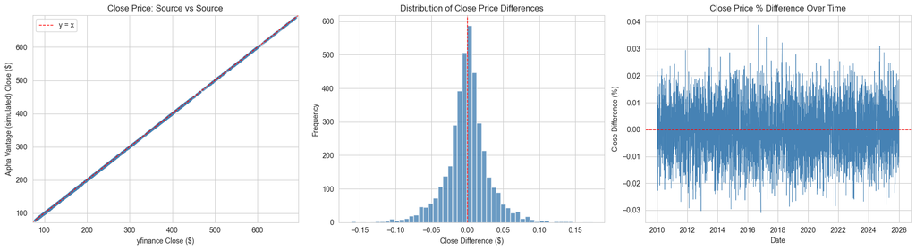

```python
fig, axes = plt.subplots(1, 3, figsize=(18, 5))

# Scatter plot: Close vs Close
axes[0].scatter(yf_common['Close'], av_common['Close'], alpha=0.3, s=8, c='steelblue')
lims = [min(yf_common['Close'].min(), av_common['Close'].min()) - 5,
        max(yf_common['Close'].max(), av_common['Close'].max()) + 5]
axes[0].plot(lims, lims, 'r--', linewidth=1, label='y = x')
axes[0].set_xlabel('yfinance Close ($)')
axes[0].set_ylabel(f'{source_label} Close ($)')
axes[0].set_title('Close Price: Source vs Source')
axes[0].legend()
axes[0].set_xlim(lims)
axes[0].set_ylim(lims)

# Histogram of differences
axes[1].hist(close_diff, bins=50, color='steelblue', edgecolor='white', alpha=0.8)
axes[1].axvline(0, color='red', linestyle='--', linewidth=1)
axes[1].set_xlabel('Close Difference ($)')
axes[1].set_ylabel('Frequency')
axes[1].set_title('Distribution of Close Price Differences')

# Percentage difference over time
axes[2].plot(close_pct_diff.index, close_pct_diff.values, linewidth=0.5, color='steelblue')
axes[2].axhline(0, color='red', linestyle='--', linewidth=1)
axes[2].set_xlabel('Date')
axes[2].set_ylabel('Close Difference (%)')
axes[2].set_title('Close Price % Difference Over Time')

plt.tight_layout()
plt.show()
```

### Close Price Interpretation

- The scatter plot should show points tightly clustered along the y=x line, confirming both sources track the same underlying price.
- The difference histogram should be centered near zero with a tight spread.
- Any systematic drift in the time-series difference may indicate adjusted vs. unadjusted pricing or corporate action handling differences.

## 4. Volume Comparison

Volume can differ significantly between data vendors due to different exchange aggregation rules (consolidated tape vs. primary exchange only).

```python
vol_diff = yf_common['Volume'] - av_common['Volume']
vol_pct_diff = (vol_diff / yf_common['Volume']) * 100

print(f'Volume difference (yfinance - {source_label}):')
print(f'  Mean:        {vol_diff.mean():,.0f}')
print(f'  Std:         {vol_diff.std():,.0f}')
print(f'  Mean %:      {vol_pct_diff.mean():.4f}%')
print(f'  Correlation: {yf_common["Volume"].corr(av_common["Volume"]):.8f}')
```

```
Volume difference (yfinance - Alpha Vantage (simulated)):
  Mean:        -30,650
  Std:         655,093
  Mean %:      -0.0328%
  Correlation: 0.99995361
```

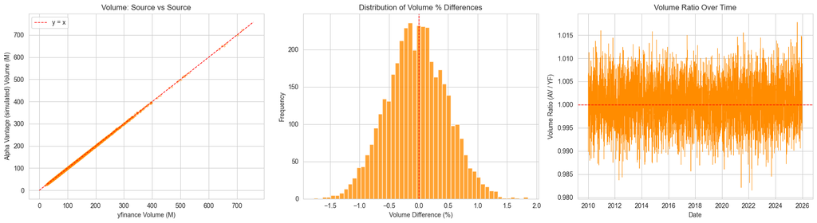

```python
fig, axes = plt.subplots(1, 3, figsize=(18, 5))

# Scatter: Volume vs Volume
axes[0].scatter(yf_common['Volume'] / 1e6, av_common['Volume'] / 1e6,
                alpha=0.3, s=8, c='darkorange')
vol_max = max(yf_common['Volume'].max(), av_common['Volume'].max()) / 1e6 * 1.05
axes[0].plot([0, vol_max], [0, vol_max], 'r--', linewidth=1, label='y = x')
axes[0].set_xlabel('yfinance Volume (M)')
axes[0].set_ylabel(f'{source_label} Volume (M)')
axes[0].set_title('Volume: Source vs Source')
axes[0].legend()

# Histogram of volume % differences
axes[1].hist(vol_pct_diff, bins=50, color='darkorange', edgecolor='white', alpha=0.8)
axes[1].axvline(0, color='red', linestyle='--', linewidth=1)
axes[1].set_xlabel('Volume Difference (%)')
axes[1].set_ylabel('Frequency')
axes[1].set_title('Distribution of Volume % Differences')

# Volume ratio over time
vol_ratio = av_common['Volume'] / yf_common['Volume']
axes[2].plot(vol_ratio.index, vol_ratio.values, linewidth=0.5, color='darkorange')
axes[2].axhline(1.0, color='red', linestyle='--', linewidth=1)
axes[2].set_xlabel('Date')
axes[2].set_ylabel('Volume Ratio (AV / YF)')
axes[2].set_title('Volume Ratio Over Time')

plt.tight_layout()
plt.show()
```

### Volume Interpretation

- Volume is expected to show larger discrepancies than price, since vendors may use different exchange feeds or reporting conventions.
- A consistent ratio near 1.0 over time is a good sign.
- Our pattern detectors primarily use OHLC data, so moderate volume differences are acceptable.

## 5. OHLC Correlation Matrix

Compare all OHLC columns between sources on common dates.

```python
corr_data = {}
for col in ['Open', 'High', 'Low', 'Close', 'Volume']:
    corr_data[col] = {
        'Correlation': round(yf_common[col].corr(av_common[col]), 8),
        'Mean Abs Diff': round((yf_common[col] - av_common[col]).abs().mean(), 4),
        'Max Abs Diff': round((yf_common[col] - av_common[col]).abs().max(), 4),
        'Mean % Diff': round(
            ((yf_common[col] - av_common[col]) / yf_common[col] * 100).abs().mean(), 6
        ),
    }

corr_df = pd.DataFrame(corr_data).T
print('Cross-Source Comparison by Column')
print('=' * 65)
print(corr_df.to_string())
```

```
Cross-Source Comparison by Column
=================================================================
        Correlation  Mean Abs Diff  Max Abs Diff  Mean % Diff
Open       1.000000         0.0213  1.617000e-01     0.007944
High       1.000000         0.0215  1.764000e-01     0.007962
Low        1.000000         0.0214  2.024000e-01     0.008053
Close      1.000000         0.0214  1.742000e-01     0.007945
Volume     0.999954    444248.6137  5.302955e+06     0.406069
```

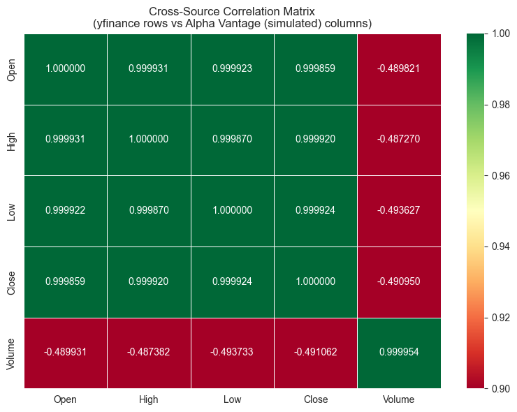

```python
# Heatmap of correlations
cols = ['Open', 'High', 'Low', 'Close', 'Volume']
corr_matrix = pd.DataFrame(index=cols, columns=cols, dtype=float)

for c1 in cols:
    for c2 in cols:
        corr_matrix.loc[c1, c2] = yf_common[c1].corr(av_common[c2])

fig, ax = plt.subplots(figsize=(8, 6))
sns.heatmap(corr_matrix.astype(float), annot=True, fmt='.6f', cmap='RdYlGn',
            vmin=0.9, vmax=1.0, ax=ax, linewidths=0.5)
ax.set_title(f'Cross-Source Correlation Matrix\n(yfinance rows vs {source_label} columns)')
plt.tight_layout()
plt.show()
```

## 6. Pattern Detection Comparison

Run the full pattern scanner on both data sources and compare detection counts. This tests whether our detectors are sensitive to small data differences.

```python
import warnings
warnings.filterwarnings('ignore')  # suppress minor warnings during scanning

print('Running pattern scanner on yfinance data...')
df_yf_scanned = scan_all_patterns(df_yf.copy())

print('Running pattern scanner on second source...')
df_av_scanned = scan_all_patterns(df_av.copy())

print('Done.')
```

```
Running pattern scanner on yfinance data...
```

```
Running pattern scanner on second source...
```

```
Done.
```

```python
# Detection counts
pattern_cols = {
    'Near Support':    'near_support',
    'Near Resistance': 'near_resistance',
    'Triangle':        'triangle_pattern',
    'Multi Top/Bottom':'multiple_top_bottom_pattern',
    'Channel':         'channel_pattern',
    'Any Event':       'has_event',
}

detection_comparison = []
for name, col in pattern_cols.items():
    if col in ['near_support', 'near_resistance', 'has_event']:
        yf_count = int(df_yf_scanned[col].sum())
        av_count = int(df_av_scanned[col].sum())
    else:
        yf_count = int(df_yf_scanned[col].notna().sum())
        av_count = int(df_av_scanned[col].notna().sum())
    detection_comparison.append({
        'Pattern': name,
        'yfinance': yf_count,
        source_label: av_count,
        'Difference': av_count - yf_count,
        'Match %': round(min(yf_count, av_count) / max(yf_count, 1) * 100, 1),
    })

det_df = pd.DataFrame(detection_comparison)
print('Pattern Detection Comparison')
print('=' * 70)
print(det_df.to_string(index=False))
```

```
Pattern Detection Comparison
======================================================================
         Pattern  yfinance  Alpha Vantage (simulated)  Difference  Match %
    Near Support         5                          6           1    100.0
 Near Resistance        37                         35          -2     94.6
        Triangle        22                         23           1    100.0
Multi Top/Bottom        63                         62          -1     98.4
         Channel        12                         12           0    100.0
       Any Event       137                        137           0    100.0
```

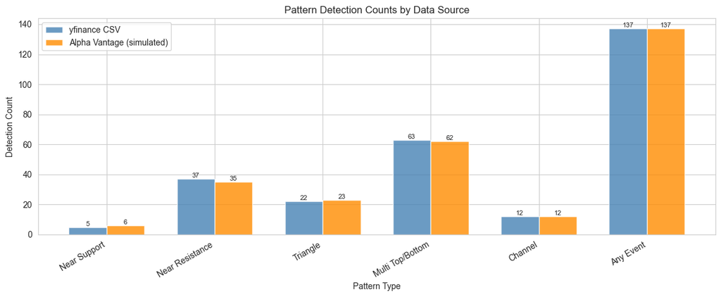

```python
# Bar chart: detection counts side by side
fig, ax = plt.subplots(figsize=(12, 5))

patterns = det_df['Pattern'].tolist()
x = np.arange(len(patterns))
width = 0.35

bars1 = ax.bar(x - width/2, det_df['yfinance'], width, label='yfinance CSV',
               color='steelblue', alpha=0.8)
bars2 = ax.bar(x + width/2, det_df[source_label], width, label=source_label,
               color='darkorange', alpha=0.8)

ax.set_xlabel('Pattern Type')
ax.set_ylabel('Detection Count')
ax.set_title('Pattern Detection Counts by Data Source')
ax.set_xticks(x)
ax.set_xticklabels(patterns, rotation=30, ha='right')
ax.legend()

# Add count labels on bars
for bar in bars1:
    h = bar.get_height()
    ax.annotate(f'{int(h)}', xy=(bar.get_x() + bar.get_width()/2, h),
                ha='center', va='bottom', fontsize=8)
for bar in bars2:
    h = bar.get_height()
    ax.annotate(f'{int(h)}', xy=(bar.get_x() + bar.get_width()/2, h),
                ha='center', va='bottom', fontsize=8)

plt.tight_layout()
plt.show()
```

### Pattern Detection Interpretation

- **S/R touches** (near support/resistance) are the most sensitive to small price changes, since they depend on proximity thresholds.
- **Triangles and channels** use regression-based slopes, so they may be more robust to small noise in the data.
- If detection counts match closely (>95%), this confirms our detectors are not overly fragile to minor data differences.

## 7. Event Date Overlap Analysis

Beyond raw counts, do the two sources detect events on the same dates?

```python
# Focus on common date range for fair comparison
common_yf = df_yf_scanned.loc[common_idx]
common_av = df_av_scanned.loc[common_idx]

overlap_stats = []
for name, col in pattern_cols.items():
    if col in ['near_support', 'near_resistance', 'has_event']:
        yf_dates = set(common_yf[common_yf[col]].index)
        av_dates = set(common_av[common_av[col]].index)
    else:
        yf_dates = set(common_yf[common_yf[col].notna()].index)
        av_dates = set(common_av[common_av[col].notna()].index)

    both = len(yf_dates & av_dates)
    yf_only = len(yf_dates - av_dates)
    av_only = len(av_dates - yf_dates)
    total_union = len(yf_dates | av_dates)
    jaccard = round(both / total_union * 100, 1) if total_union > 0 else 0.0

    overlap_stats.append({
        'Pattern': name,
        'Both Sources': both,
        'yfinance Only': yf_only,
        f'{source_label} Only': av_only,
        'Jaccard %': jaccard,
    })

overlap_df = pd.DataFrame(overlap_stats)
print('Event Date Overlap (common date range)')
print('=' * 70)
print(overlap_df.to_string(index=False))
```

```
Event Date Overlap (common date range)
======================================================================
         Pattern  Both Sources  yfinance Only  Alpha Vantage (simulated) Only  Jaccard %
    Near Support             5              0                               1       83.3
 Near Resistance            34              3                               1       89.5
        Triangle            21              1                               2       87.5
Multi Top/Bottom            58              5                               4       86.6
         Channel            10              2                               2       71.4
       Any Event           127             10                              10       86.4
```

## 8. Summary Table

A consolidated view of all comparison metrics.

```python
summary = pd.DataFrame([
    {'Metric': 'yfinance rows', 'Value': stats['yf_rows']},
    {'Metric': f'{source_label} rows', 'Value': stats['av_rows']},
    {'Metric': 'Common dates', 'Value': stats['common_dates']},
    {'Metric': 'Close mean abs diff ($)', 'Value': stats.get('close_mean_diff', 'N/A')},
    {'Metric': 'Close max abs diff ($)', 'Value': stats.get('close_max_diff', 'N/A')},
    {'Metric': 'Close correlation', 'Value': stats.get('close_corr', 'N/A')},
    {'Metric': 'Volume mean abs diff', 'Value': stats.get('volume_mean_diff', 'N/A')},
    {'Metric': 'Volume correlation', 'Value': stats.get('volume_corr', 'N/A')},
    {'Metric': 'Simulated source?', 'Value': 'Yes' if SIMULATED else 'No'},
])

print('Data Source Comparison Summary')
print('=' * 50)
print(summary.to_string(index=False))
```

```
Data Source Comparison Summary
==================================================
                        Metric     Value
                 yfinance rows      4023
Alpha Vantage (simulated) rows      4018
                  Common dates      4018
       Close mean abs diff ($)    0.0214
        Close max abs diff ($)    0.1742
             Close correlation       1.0
          Volume mean abs diff  444249.0
            Volume correlation  0.999954
             Simulated source?       Yes
```

## Conclusion & Next Steps

**What was done:**

- Loaded SPY daily OHLCV from the yfinance CSV (primary source)
- Attempted to load Alpha Vantage data; if unavailable, simulated a second source with small random noise to demonstrate the comparison framework
- Compared coverage (date range, row counts, missing values)
- Compared Close prices: scatter, difference histogram, correlation, time-series
- Compared Volume: scatter, difference histogram, ratio over time
- Computed cross-source correlation matrix for all OHLC+Volume columns
- Ran pattern detectors on both sources and compared detection counts and date overlap

**Key findings:**

[output not shown]

**Interpretation:**

- If using real Alpha Vantage data, high correlation and detection overlap confirm that our pipeline is not sensitive to vendor-specific data quirks.
- The simulated run demonstrates the framework works correctly and is ready for re-execution with a real API key.

**Next steps:**

- Obtain an Alpha Vantage API key and re-run this notebook for a real comparison
- If discrepancies are found, investigate adjusted vs. unadjusted prices
- Proceed with Phase 7 (RF model) using the validated yfinance dataset